# Determinanti del tassodi incidentalità stradale

Autore/Autrice

Giulio Mela

## Introduzione

Le città italiane sono caratterizzate da tassi di incidentalità (facenti riferimento sia agli incidenti mortali che a quelli non mortali) sensibilmente più alti di quelli di molte altre città europee, sopratutto di quelle dei paesi dove la mobilità attiva rappresenta un’ampia percentuale degli spostamenti totali (Paesi Bassi, Germania, Danimarca, ecc.), come evidenziato dal rapporto dell’International Transport Forum sulla sicurezza stradale nelle città europee (International Transport Forum 2019). Inoltre, i rischio di incidenti, mortali e non, è sistematicamente maggiore per pedoni e ciclisti rispetto a chi utilizza i mezzi pubblici o auto e moto private, come da dati ISTAT sugli incidenti avvenuti in Italia (Istat 2024). L’elevato rischio incidenti per pedoni e ciclisti rischia di annullare gli effetti positivi di un eventuale passaggio dalla mobilità passiva alla mobilità attiva di parte degli spostamenti quotidiani nelle città italiane, nell’ipotesi che tale passaggio non sia in grado - contestualmente - di ridurre i volumi di traffico motorizzato in maniera sufficiente a ridurre anche il rischio incidenti.

## Scopo dell’analisi

Nel corso delle attività RDS 2024, viene sviluppato uno scenario di mobilità alternativa per la città di Milano che prevede l’effettuazione di determinate percentuali degli spostamenti giornalieri (suddivisi per lunghezza del percorso) tramite bicicletta o a piedi, invece che con mezzi a motore privati. Lo scenario è arricchito anche dalla realizzazione di zone 30 e di nuove infrastrutture ciclabili. L’obiettivo è quello di valutare gli effetti sull’inquinamento, la congestione stradale e la salute di tale scenario. Il passaggio da una mobilità di tipo passivo a una di tipo attivo genera benefici per la salute grazie alla maggiore attività fisica (anche se possono essere parzialmente erosi dalla maggior inalazione di inquinanti), ma con la grande incognita del rischio incidenti che in alcune città è così elevato da azzerare completamente i benefici dovuti dalla maggior attività fisica. Questo nell’ipotesi che il rischio incidenti non cambi nello scenario alternativo, un’ipotesi forte.

Per poter meglio stimare gli effetti sulla salute, quindi, è necessario stimare il rischio incidenti anche nello scenario alternativo ovverosia con l’istituzione delle zone 30 e la costruzione di nuove piste ciclabili, oltre con una determinata riduzione del traffico motorizzato. Una strategia potrebbe essere quella di utilizzare i tassi di incidentalità di città contraddistinte da un’estensione dell infrastrutture ciclabili (per popolazione residente) e di percentuale di traffico motorizzato sul totale, simili a quelli della città di Milano nello scenario alternativo. È quindi necessario individuare la relazione causale tra rischio incidenti di ciclisti e pedoni e alcune variabili che possono influenzare questo rischio.

Da un’analisi della letteratura (Adminaité-Fodor e Jost 2020; European Commission 2022; International Transport Forum 2019; Castro, Kahlmeier, e Götschi 2018) è emerso che i *driver* del rischio incidenti in ambito urbano per i ciclisti possono essere riassunti nelle seguenti variabili:

- Densità di popolazione (maggior congestione del traffico, minori velocità medie, maggior percentuale di persone che usa i mezzi pubblici).
- Estensione dell’infrastruttura ciclabile.
- Volume di traffico motorizzato sul totale.
- Presenza di aree con limiti di velocità a 30 km/h (soglia oltre la quale le conseguenze di un impatto con un veicolo a motore, per ciclisti e pedoni, sono prevalentemente mortali).
- Stato delle infrastrutture stradali (es. asfalto).
- Utilizzo del casco.
- Età del ciclista.

## Analisi statistica

L’obiettivo è quello di quantificare la relazione causale - individuata dalla letteratura - tra tasso di incidentalità e alcune variabili esplicative: densità di popolazione, estensione delle ciclabili per unità di popolazione e volume di traffico motorizzato sul totale. Ogni capoluogo di provincia rappresenta un’osservazione. Sono state anche aggiunte delle variabili *dummy* corrispondenti alle varie aree geografiche di appartenenza (Nord-Ovest, Nord-Est, Centro, Sud e Isole) in modo da rappresentare eventuali differenze di carattere geografico e sociale. Sono state stimate cinque versioni di questa relazione, una per ogni classe di età.

Poiché la relazione tra tasso di incidentalità e le variabili indipendenti è molto probabilmente non-lineare, le varie versioni del modello vengono stimate a valle di una trasformazione logaritmica delle variabili stesse. La Figura 1 e la Figura 2 mostrano la distribuzione delle variabili prima e dopo la trasformazione logaritmica.

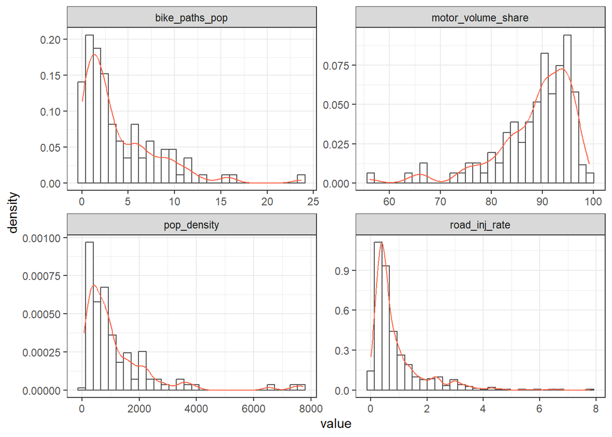

Figura 1: Distribuzione delle variabili utilizzate (livelli)

Una volta trasformati i dati, la distribuzione delle variabili è molto più simile alla distribuzione normale

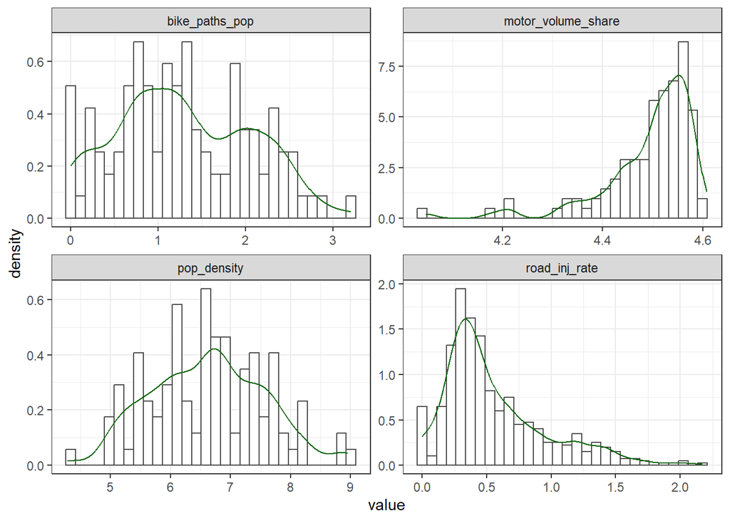

Figura 2: Distribuzione delle variabili utilizzate (logaritmi)

La Figura 3 mostra infine le linee di regressione tra la variabile dipendente (tasso di incidentalità) e ciascuna delle variabili indipendenti separatamente. Tutte e tre le variabili sembrano almeno parzialmente correlate con la variabile dipendente, per tutte le classi di età considerate. La classe di età che mostra la correlazione minore è quella tra 65 e 120 anni, in quanto, al di sopra di una certa età, è più probabile che, tra le cause di un incidente, possa esserci anche la scarsa prestanza fisica dei soggetti coinvolti. Osservando il grafico salta all’occhio un potenziale problema che andrà risolto in fase di stima vera e propria e vale a dire che le linee di regressione in alcuni casi assumono valori negativi, mentre il tasso di incidentalità è positivo per definizione. Per ora proseguiamo l’analisi con la “normale” regressione lineare, ma in seguito potremmo dover utilizzare modelli specificatamente ideati per gestire situazioni nelle quali la variabile dipendente deve rimanere confinata entro certi limiti, come la [*beta regression*](https://www.andrewheiss.com/blog/2021/11/08/beta-regression-guide/) (più utile nel caso in cui la variabile dipendente sia una proporzione) o i modelli tobit, specificatamente ideati per situazioni nelle quali la variabile dipendente è continua, ma sempre uguale o superiore a un determinato valore (es. zero).

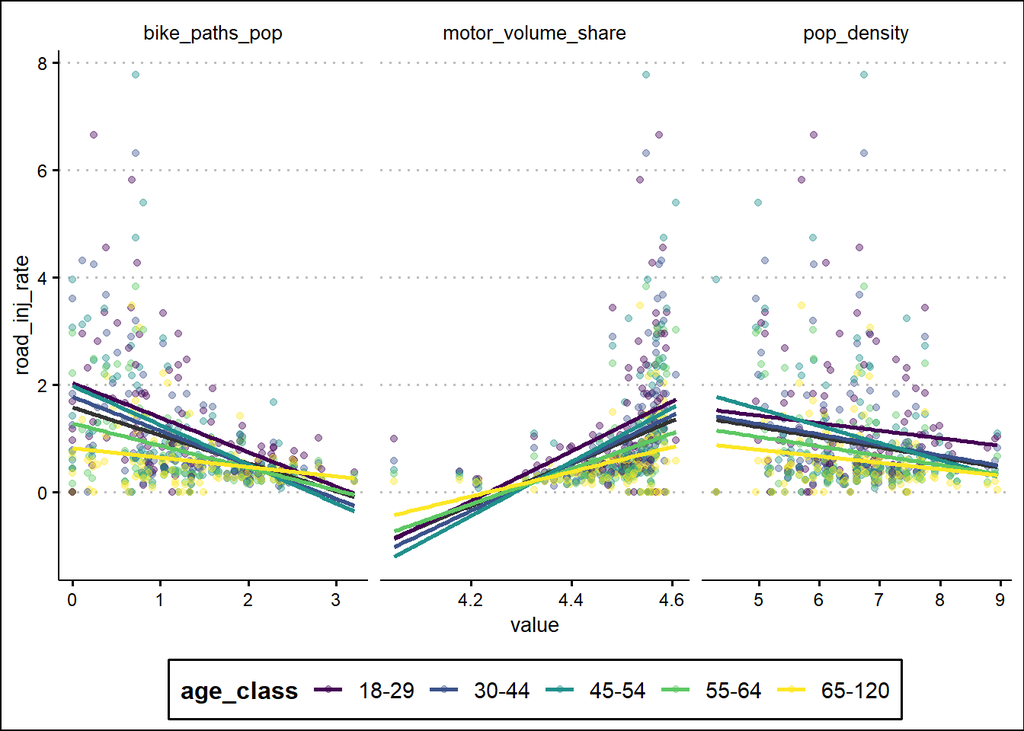

Figura 3: Relazioni biunivoche tra la variabile dipendente e ciascuno dei regressori

# Regressione lieare semplice (OLS) e modello Tobit

Nel modello lineare (*Ordinary Least Squares*) del tipo:

$$Y_i = \alpha + \beta X_i + \epsilon_i
\tag{1}$$

il coefficiente $\beta$ rappresenta la variazione della variabile dipendente $Y$ data una variazione unitaria della variabile indipendente $X$. Quando vengono utilizzate, in entrambi i lati dell’equazione, i logaritmi delle variabili, il coefficiente $\beta$ può essere interpretato come la variazione percentuale di $Y$ a fronte della variazione di $X$ dell’1%.

Questo tipo di modelli si presta solo parzialmente alla nostra analisi in quanto la variabile dipendente (tasso di incidentalità) è sempre maggiore o uguale a zero. In questo caso è infatti preferibile un modello *tobit*. Il modello tobit prende il suo nome dal James Tobin che lo sviluppò per descrivere la relazione tra una variabile dipendente non negativa $Y_i$ e una (o più) variabile indipendente $x_i$. Il modello *tobit* è concettualmente simile al modello *probit*, che viene usato nel caso di variabili dipendenti binarie. Il modello ipotizza che una variabile latente e non osservabile $y_{i}^{*}$ dipenda linearmente da $x_i$ tramite un vettore di parametri $\beta$ e da un termine di errore distribuito normalmente $u_i$, in maniera analoga al modello lineare OLS. La variabile osservabile (nel nostro caso il tasso di incidentalità) $y_i$ è ipotizzata uguale alla variabile latente $y_{i}^{*}$ quando quest’ultima è maggiore di zero e zero in tutti gli altri casi:

$$\begin{equation}
y_{i} =
\begin{cases}
y_{i}^{*} \quad \text{se} \quad y_{i}^{*} > 0 \\
0 \quad \text{se} \quad y_{i}^{*} \leq 0 \\
\end{cases}
\end{equation}
\tag{2}$$

Dove $y_{i}^{*}$ è la variabile latente:

$$y_{i}^{*} = \beta x_i + u_i, \quad u_i \sim N(0, \sigma^2)
\tag{3}$$

Il modello *tobit* viene anche chiamato *censored regression model*, cioè un modello di regressione lineare nel quale tutti i valori negativi (nel nostro caso) vengono posti uguali a zero. In altre parole, le osservazioni vengono censurate a zero. Il modello, quindi, descrive due cose. La prima è la probabilità che $y_i = 0$ dato $x_i$, che in termini matematici può essere espressa come:

$$P \{ y_i = 0\} = P \{ y_{i}^{*} \leq 0 \} = P \{ \epsilon_i \leq -x_{i}^{'} \beta\} = P \biggl\{ \frac{\epsilon_i}{\sigma} \leq \; -\frac{x_{i}^{'} \beta}{\sigma} \biggr\} = \Phi \bigg(-\frac{x_{i}^{'} \beta}{\sigma} \bigg) = 1 - \Phi \bigg(\frac{x_{i}^{'} \beta}{\sigma} \bigg)
\tag{4}$$

La seconda è invece la distribuzione di $y_i$ quando è positiva, che altro non è che una distribuzione normale troncata con valore atteso:

$$E\{ y_i|yi >0\} = x_{i}^{'} \beta + E\{ \epsilon_i|\epsilon_i > -x_{i}^{'} \beta\} = x_{i}^{'} \beta + \sigma \frac{\phi(x_{i}^{'} \beta/\sigma)}{\Phi(x_{i}^{'} \beta)}
\tag{5}$$

L’ultimo termine della Equazione 5 è il valore atteso di una variabile distribuita normalmente con media zero che sia più grande di $-x_i\beta$ e tale valore atteso è sempre maggiore di zero. L’Equazione 5 mostra cosa sarebbe inappropriato utilizzare solo le osservazioni positive e stimare un modello di regressione lineare solo su di esse. Infatti, il valore atteso condizionale di $y_i$ non è più uguale a $x_{i}{'}\beta$ ma dipende anche, non linearmente, da $x_i$ tramite $\frac{\phi(x_{i}^{'} \beta/\sigma)}{\Phi(x_{i}^{'} \beta)}$.

I coefficienti del modello *tobit* possono essere interpretati in molti modi, a seconda delle esigenze. Ad esempio, la probabilità che $y_i = 0$ è data da:

$$P\{ y_i = 0\} = 1 - \Phi(x_{i}^{'}\beta / \sigma)
\tag{6}$$

nel quale $\beta / \sigma$ è l’effetto marginale di una variazione di $x_{ik}$ data la probabilità di osservare un valore nullo, cioè:

$$\frac{\delta P\{ y_i = 0\}}{\delta x_{ik}} = -\Phi(x_{i}^{'}/\sigma)\frac{b_k}{\sigma}
\tag{7}$$

Il modello *tobit* descrive anche il valore atteso di $y_i$ quando questo è positivo, ovverosia l’effetto marginale di una variazione in $x_{ik}$ sul valore di $y_i$ data la troncazione. In altre parole, tale effetto è diverso da $\beta_k$, cioè il coefficiente della regressione lineare. L’effetto marginale di una variazione di $x_{ik}$ sul valore atteso di $y_i$ è dato da:

$$\frac{E\{ y_i\}}{\delta x_{ik}} = \beta_k \Phi(x_{i}^{'}\beta / \sigma)
\tag{8}$$

L’Equazione 8 ci dice che l’effetto marginale di una variazione in $x_{ik}$ su $y_i$ è dato dal coefficiente $\beta_k$ moltiplicato per la probabilità di avere un outcome positivo. Se la probabilità è 1, allora l’effetto marginale è $\beta_k$, come per il modello lineare.

La stima del modello *tobit* avviene normalmente con il metodo della massima verosimiglianza

Prime stime

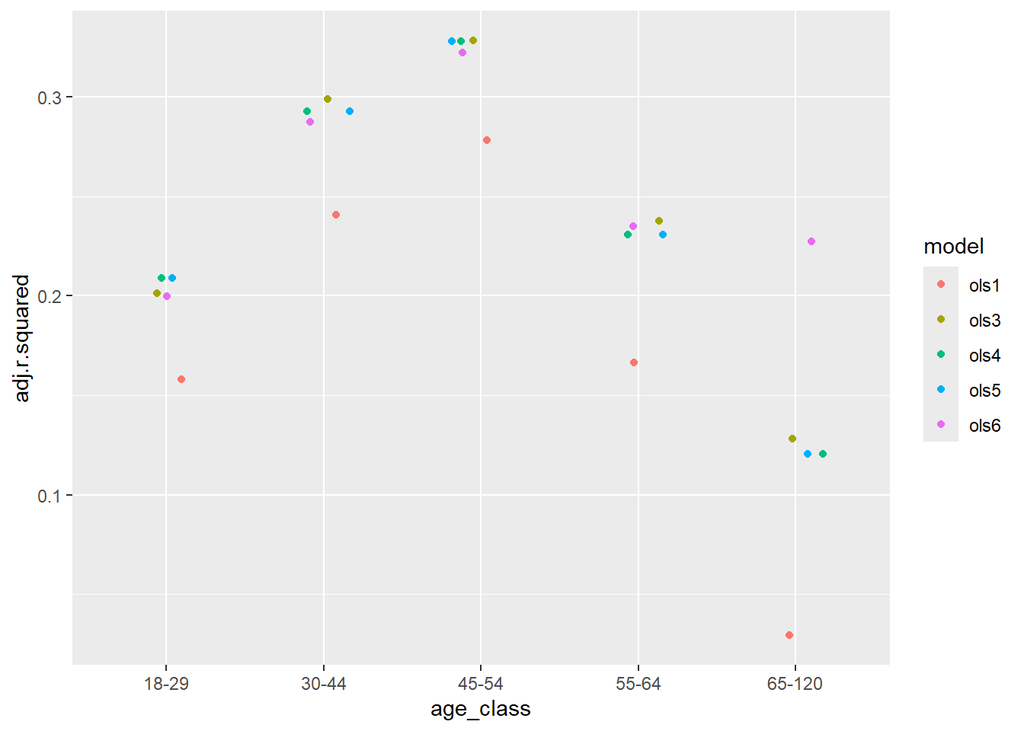

## Referenze

Adminaité-Fodor, Dovilé, e Graziella Jost. 2020. «How Safe Is Walking and Cycling in Europe?» {{PIN Flash Report}} 38. Bruxelles: European Transport Safety Council.

Castro, Alberto, Sonja Kahlmeier, e Thomas Götschi. 2018. «Exposure-Adjusted Road Fatality Rates for Cycling and Walking in European Countries». Discussion Paper 168. Vol. 2018/05. International Transport Forum Discussion Papers. Paris: International Transport Forum. https://doi.org/10.1787/fd022267-en.

European Commission. 2022. «Road Safety Thematic Report - Cyclists». Bruxelles: European Road Safety Observatory. European Commission, Directorate General for Transport.

International Transport Forum. 2019. «Road Safety in European Cities - Performance Indicators and Governance Solutions». 67. Paris: OECD Publishing.

Istat. 2014. «Matrici del pendolarismo». https://www.istat.it/it/archivio/139381.

———. 2024. «Rilevazione degli incidenti stradali con lesioni a persone. Edizione 2024 – Istat».

Magliulo, Claudio, e Marco Talluri. 2022. «Non è Un Paese per Bici - Come Rendere Ciclabili Le Città Italiane: Piani, Scenari, Risorse». Clean Cities Initiative.